# Differential Expression (DESeq2) — Exploratory Data Analysis

SoundLife healthy-cohort pseudobulk scRNA-seq · results dated 2025-02-07

Four contrasts: Age Group · Biological Sex · CMV Status · Flu Vaccine

## 1. Summary at a glance

4

comparisons

1,498,504

total DEG tests

10,629

significant (padj<0.05)

360

strong (&|log2FC|≥1)

A "test" = one gene in one cell type (AIFI_L3) for one contrast. positive log2FC ⇒ higher expression in the Foreground group.

## 2. Dataset overview

| Comparison | scRNA column | Background | Foreground | Rows | Cell types | Genes | NA padj | Sig (padj<0.05) | % Sig | Strong | Up | Down |
| --- | --- | --- | --- | --- | --- | --- | --- | --- | --- | --- | --- | --- |
| **Age Group** | `cohort.cohortGuid` | BR1 Younger Adult | BR2 Older Adult | 373,942 | 71 | 11,454 | 56,647 | 1,652 | 0.4% | 5 | 891 | 761 |
| **Biological Sex** | `subject.biologicalSex` | Female | Male | 373,942 | 71 | 11,454 | 2,479 | 1,631 | 0.4% | 315 | 549 | 1,082 |
| **CMV Status** | `subject.cmv` | Negative | Positive | 373,942 | 71 | 11,454 | 6,962 | 214 | 0.1% | 32 | 116 | 98 |
| **Flu Vaccine** | `sample.visitName` | Flu Year 1 Day 0 | Flu Year 1 Day 7 | 376,678 | 71 | 11,508 | 60,893 | 7,132 | 1.9% | 8 | 3,116 | 4,016 |

"Strong" = padj<0.05 AND |log2FC|≥1. "Up"/"Down" count significant tests with positive/negative log2FC.

## 4. Significant results by comparison

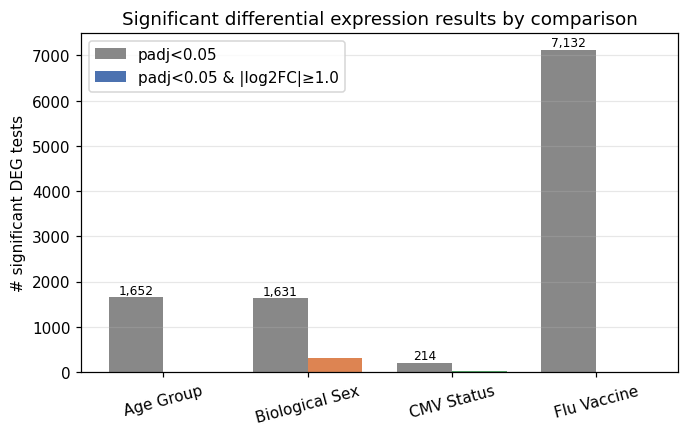

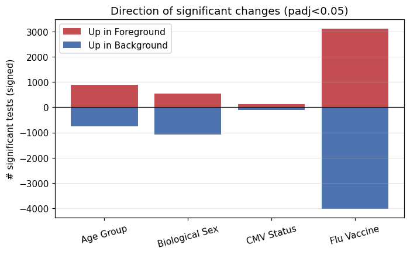

## 5. Volcano plots

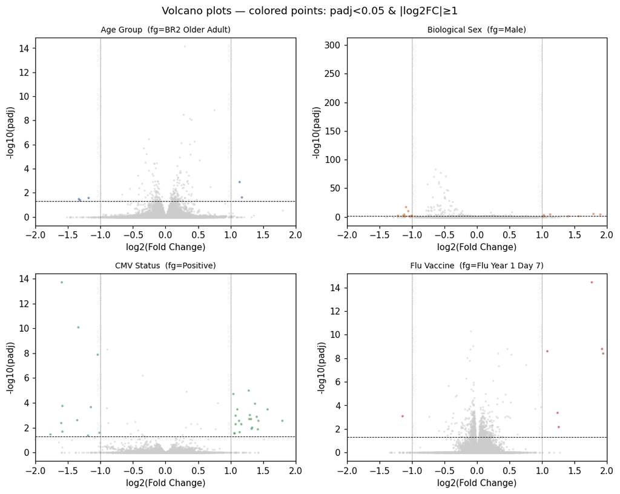

Grey = non-significant (subsampled for rendering). Colored = padj<0.05 & |log2FC|≥1. Dashed line = padj 0.05 threshold; dotted lines = ±1 log2FC.

## 6. p-value & effect-size diagnostics

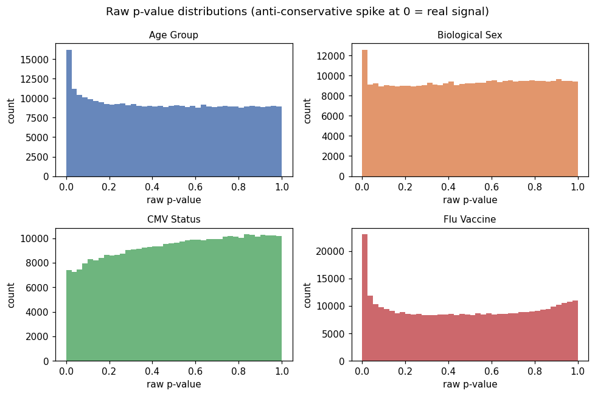

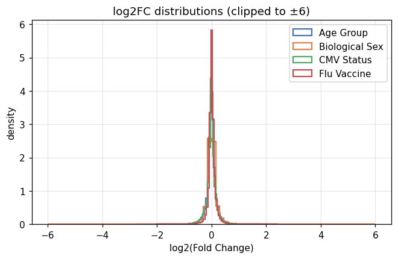

Left: well-behaved DESeq2 output shows a uniform background with a spike near p=0 where true signal exists. Right: log2FC are centered near 0 with heavier tails for stronger contrasts.

## 7. Where is the signal? Cell-type landscape

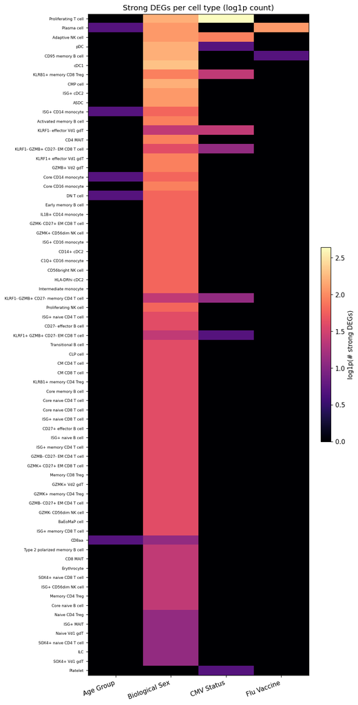

Cell type **Proliferating T cell** carries the most strong DEGs summed across comparisons. Rows ordered by total signal.

## 8. Per-comparison detail

### Age Group

**Contrast:** Foreground = BR2 Older Adult vs Background = BR1 Younger Adult | column `cohort.cohortGuid`

1,652 tests significant at padj<0.05 (0.4% of 373,942), of which **5** also have |log2FC|≥1.

#### Top 15 results by padj

| Cell type | Gene | log2FC | padj | Direction |
| --- | --- | --- | --- | --- |
| Core naive CD4 T cell | **VMP1** | 0.30 | 7.03e-15 | Up (Foreground) |
| Core naive CD4 T cell | **USP10** | 0.55 | 3.35e-13 | Up (Foreground) |
| Core naive CD4 T cell | **TSHZ2** | 0.51 | 5.14e-13 | Up (Foreground) |
| Core naive CD4 T cell | **SH2D1A** | -0.30 | 2.43e-11 | Down (Background) |
| Core naive CD4 T cell | **AHNAK** | 0.64 | 4.46e-11 | Up (Foreground) |
| Core naive CD4 T cell | **TMEM263** | -0.23 | 4.46e-11 | Down (Background) |
| Core naive CD4 T cell | **TRADD** | 0.35 | 7.06e-11 | Up (Foreground) |
| Core naive CD4 T cell | **INPP4B** | 0.37 | 7.06e-11 | Up (Foreground) |
| Core naive CD4 T cell | **AP3M2** | 0.39 | 7.06e-11 | Up (Foreground) |
| Core naive CD4 T cell | **NUCB2** | -0.25 | 8.47e-11 | Down (Background) |
| Core naive CD4 T cell | **STK17A** | -0.31 | 1.18e-10 | Down (Background) |
| Core naive CD4 T cell | **CASP1** | 0.31 | 1.18e-10 | Up (Foreground) |
| Core naive CD8 T cell | **ANXA1** | 0.90 | 3.64e-10 | Up (Foreground) |
| Core naive CD4 T cell | **LEF1** | -0.18 | 1.03e-09 | Down (Background) |
| Core naive CD8 T cell | **AHNAK** | 0.75 | 1.34e-09 | Up (Foreground) |

#### Most differentially active cell types

1. CD8aa — **1**
2. Core CD14 monocyte — **1**
3. DN T cell — **1**
4. ISG+ CD14 monocyte — **1**
5. Plasma cell — **1**

### Biological Sex

**Contrast:** Foreground = Male vs Background = Female | column `subject.biologicalSex`

1,631 tests significant at padj<0.05 (0.4% of 373,942), of which **315** also have |log2FC|≥1.

#### Top 15 results by padj

| Cell type | Gene | log2FC | padj | Direction |
| --- | --- | --- | --- | --- |
| C1Q+ CD16 monocyte | **RPS4Y1** | 7.07 | 0.00e+00 | Up (Foreground) |
| CD8 MAIT | **XIST** | -5.93 | 0.00e+00 | Down (Background) |
| CD14+ cDC2 | **XIST** | -7.86 | 0.00e+00 | Down (Background) |
| CD14+ cDC2 | **RPS4Y1** | 6.99 | 0.00e+00 | Up (Foreground) |
| CD27+ effector B cell | **RPS4Y1** | 7.52 | 0.00e+00 | Up (Foreground) |
| CM CD4 T cell | **DDX3Y** | 6.63 | 0.00e+00 | Up (Foreground) |
| CM CD4 T cell | **EIF1AY** | 6.70 | 0.00e+00 | Up (Foreground) |
| Core CD16 monocyte | **XIST** | -7.32 | 0.00e+00 | Down (Background) |
| Core CD16 monocyte | **RPS4Y1** | 6.66 | 0.00e+00 | Up (Foreground) |
| Core memory B cell | **XIST** | -6.81 | 0.00e+00 | Down (Background) |
| Core memory B cell | **RPS4Y1** | 7.02 | 0.00e+00 | Up (Foreground) |
| Core memory B cell | **EIF1AY** | 7.43 | 0.00e+00 | Up (Foreground) |
| Core naive B cell | **XIST** | -5.98 | 0.00e+00 | Down (Background) |
| Core naive B cell | **RPS4Y1** | 6.70 | 0.00e+00 | Up (Foreground) |
| Core naive B cell | **EIF1AY** | 7.74 | 0.00e+00 | Up (Foreground) |

#### Most differentially active cell types

1. cDC1 — **9**
2. pDC — **8**
3. CD95 memory B cell — **8**
4. Proliferating T cell — **8**
5. CMP cell — **8**
6. Plasma cell — **7**
7. ISG+ cDC2 — **7**
8. ASDC — **7**

### CMV Status

**Contrast:** Foreground = Positive vs Background = Negative | column `subject.cmv`

214 tests significant at padj<0.05 (0.1% of 373,942), of which **32** also have |log2FC|≥1.

#### Top 15 results by padj

| Cell type | Gene | log2FC | padj | Direction |
| --- | --- | --- | --- | --- |
| KLRF1- GZMB+ CD27- EM CD8 T cell | **CD27** | -1.60 | 1.87e-14 | Down (Background) |
| KLRF1- GZMB+ CD27- EM CD8 T cell | **LYST** | -0.70 | 1.03e-12 | Down (Background) |
| Adaptive NK cell | **JAK1** | -0.38 | 4.23e-11 | Down (Background) |
| Adaptive NK cell | **SELL** | -1.34 | 7.62e-11 | Down (Background) |
| Adaptive NK cell | **FCER1G** | -0.90 | 5.14e-09 | Down (Background) |
| KLRF1- GZMB+ CD27- EM CD8 T cell | **DSTN** | 0.38 | 1.07e-08 | Up (Foreground) |
| Adaptive NK cell | **GCHFR** | -1.04 | 1.32e-08 | Down (Background) |
| Adaptive NK cell | **CEBPD** | -0.83 | 2.77e-08 | Down (Background) |
| KLRF1- GZMB+ CD27- EM CD8 T cell | **FCMR** | -0.35 | 6.28e-07 | Down (Background) |
| KLRF1- GZMB+ CD27- EM CD8 T cell | **SCML4** | 0.46 | 6.28e-07 | Up (Foreground) |
| KLRF1- GZMB+ CD27- EM CD8 T cell | **MXRA7** | 0.55 | 4.57e-06 | Up (Foreground) |
| KLRF1+ GZMB+ CD27- EM CD8 T cell | **GPR183** | -0.93 | 6.53e-06 | Down (Background) |
| KLRF1- GZMB+ CD27- EM CD8 T cell | **LINC02446** | 1.28 | 1.00e-05 | Up (Foreground) |
| KLRF1- GZMB+ CD27- EM CD8 T cell | **SAP30** | 0.40 | 1.00e-05 | Up (Foreground) |
| KLRF1- GZMB+ CD27- EM CD8 T cell | **KLRD1** | 0.32 | 1.17e-05 | Up (Foreground) |

#### Most differentially active cell types

1. Proliferating T cell — **13**
2. Adaptive NK cell — **6**
3. KLRB1+ memory CD8 Treg — **3**
4. KLRF1- effector Vd1 gdT — **3**
5. KLRF1- GZMB+ CD27- EM CD8 T cell — **2**
6. KLRF1- GZMB+ CD27- memory CD4 T cell — **2**
7. KLRF1+ GZMB+ CD27- EM CD8 T cell — **1**
8. Platelet — **1**

### Flu Vaccine

**Contrast:** Foreground = Flu Year 1 Day 7 vs Background = Flu Year 1 Day 0 | column `sample.visitName`

7,132 tests significant at padj<0.05 (1.9% of 376,678), of which **8** also have |log2FC|≥1.

#### Top 15 results by padj

| Cell type | Gene | log2FC | padj | Direction |
| --- | --- | --- | --- | --- |
| Plasma cell | **B4GALT1** | 1.76 | 3.37e-15 | Up (Foreground) |
| CD95 memory B cell | **SMIM14** | 0.79 | 6.17e-12 | Up (Foreground) |
| CD27+ effector B cell | **CXCR3** | 0.71 | 6.44e-12 | Up (Foreground) |
| CD27+ effector B cell | **RPS23** | -0.12 | 2.74e-11 | Down (Background) |
| CD27+ effector B cell | **RPL11** | -0.10 | 4.86e-11 | Down (Background) |
| CD27+ effector B cell | **RPL29** | -0.10 | 6.54e-11 | Down (Background) |
| CD27+ effector B cell | **RPL13** | -0.12 | 6.54e-11 | Down (Background) |
| CD27+ effector B cell | **DAPP1** | 0.27 | 1.23e-10 | Up (Foreground) |
| CD27+ effector B cell | **SMIM14** | 0.26 | 2.17e-10 | Up (Foreground) |
| Plasma cell | **SEL1L3** | 0.47 | 3.79e-10 | Up (Foreground) |
| CD95 memory B cell | **MS4A1** | 0.28 | 4.13e-10 | Up (Foreground) |
| CD27+ effector B cell | **RPS27A** | -0.13 | 4.21e-10 | Down (Background) |
| CD95 memory B cell | **ZEB2** | 0.63 | 4.55e-10 | Up (Foreground) |
| CD27+ effector B cell | **RPL32** | -0.11 | 5.16e-10 | Down (Background) |
| CD27+ effector B cell | **RPL10** | -0.10 | 7.34e-10 | Down (Background) |

#### Most differentially active cell types

1. Plasma cell — **7**
2. CD95 memory B cell — **1**